# Pokémon Attack Stat GLM Analysis

# 4. Attack GLM Models

## 4.1 Model 1: Simple Generation Effect

Before fitting the model, let’s visualize what Attack looks like across generations to understand what the model will capture:

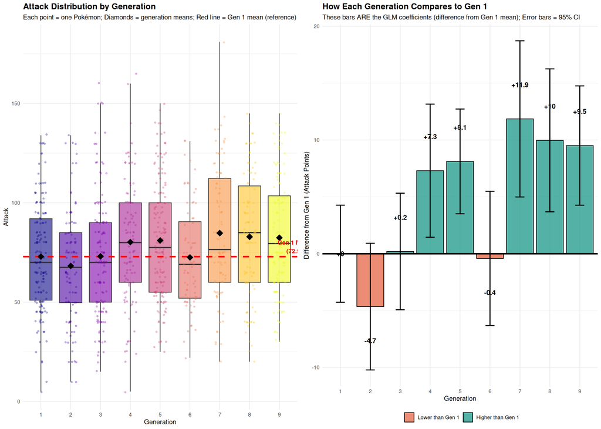

```r
# ═══════════════════════════════════════════════════════════════════
# VISUALIZING ATTACK BY GENERATION (What the Simple Model Captures)
# ═══════════════════════════════════════════════════════════════════

# Calculate generation means and Gen 1 reference
gen1_mean <- mean(pokemon$attack[pokemon$gen == "1"])

gen_stats <- pokemon %>%
  group_by(gen) %>%
  summarise(
    n = n(),
    mean_attack = mean(attack),
    median_attack = median(attack),
    sd_attack = sd(attack),
    se = sd(attack) / sqrt(n()),
    diff_from_gen1 = mean(attack) - gen1_mean
  ) %>%
  mutate(
    significant = abs(diff_from_gen1) / se > 1.96,  # Approximate significance
    label = paste0(ifelse(diff_from_gen1 >= 0, "+", ""), round(diff_from_gen1, 1))
  )

# PLOT 1: Boxplot with individual points and Gen 1 reference
p1 <- ggplot(pokemon, aes(x = gen, y = attack)) +
  geom_boxplot(aes(fill = gen), alpha = 0.6, outlier.shape = NA) +
  geom_jitter(aes(color = gen), width = 0.2, alpha = 0.3, size = 1) +
  geom_hline(yintercept = gen1_mean, linetype = "dashed",
             color = "red", linewidth = 1.2) +
  stat_summary(fun = mean, geom = "point", shape = 18, size = 5, color = "black") +
  annotate("text", x = 9.5, y = gen1_mean + 5, label = paste0("Gen 1 Mean\n(", round(gen1_mean, 1), ")"),
           color = "red", fontface = "bold", size = 3.5) +
  scale_fill_viridis_d(option = "plasma", guide = "none") +
  scale_color_viridis_d(option = "plasma", guide = "none") +
  labs(title = "Attack Distribution by Generation",
       subtitle = "Each point = one Pokémon; Diamonds = generation means; Red line = Gen 1 mean (reference)",
       x = "Generation", y = "Attack") +
  theme_minimal() +
  theme(plot.title = element_text(size = 14, face = "bold"))

# PLOT 2: Bar chart showing difference from Gen 1 (= GLM coefficients)
p2 <- ggplot(gen_stats, aes(x = gen, y = diff_from_gen1, fill = diff_from_gen1 > 0)) +
  geom_bar(stat = "identity", alpha = 0.8, color = "black") +
  geom_errorbar(aes(ymin = diff_from_gen1 - 1.96*se, ymax = diff_from_gen1 + 1.96*se),
                width = 0.3, linewidth = 0.8) +
  geom_hline(yintercept = 0, linewidth = 1.2, color = "black") +
  geom_text(aes(label = label, y = diff_from_gen1 + sign(diff_from_gen1) * 3),
            size = 4, fontface = "bold") +
  scale_fill_manual(values = c("TRUE" = "#2A9D8F", "FALSE" = "#E76F51"),
                    labels = c("TRUE" = "Higher than Gen 1", "FALSE" = "Lower than Gen 1"),
                    name = "") +
  labs(title = "How Each Generation Compares to Gen 1",
       subtitle = "These bars ARE the GLM coefficients (difference from Gen 1 mean); Error bars = 95% CI",
       x = "Generation", y = "Difference from Gen 1 (Attack Points)") +
  theme_minimal() +
  theme(plot.title = element_text(size = 14, face = "bold"),
        legend.position = "bottom")

# PLOT 3: Mean trajectory with trend line
p3 <- ggplot(gen_stats, aes(x = as.numeric(as.character(gen)), y = mean_attack)) +
  geom_line(linewidth = 1.2, color = "#264653") +
  geom_point(aes(size = n), color = "#E76F51", alpha = 0.8) +
  geom_smooth(method = "lm", se = TRUE, color = "#2A9D8F",
              linetype = "dashed", linewidth = 1) +
  geom_hline(yintercept = gen1_mean, linetype = "dotted",
             color = "red", linewidth = 1) +
  scale_x_continuous(breaks = 1:9) +
  scale_size_continuous(range = c(4, 10), name = "n Pokémon") +
  labs(title = "Attack Mean Trajectory Across Generations",
       subtitle = "Dashed line = linear trend; Dotted red = Gen 1 baseline; Point size = sample size",
       x = "Generation", y = "Mean Attack") +
  theme_minimal() +
  theme(plot.title = element_text(size = 14, face = "bold"))

# PLOT 4: Summary table as visualization
gen_table <- gen_stats %>%
  dplyr::select(gen, n, mean_attack, diff_from_gen1) %>%
  mutate(
    mean_attack = round(mean_attack, 1),
    diff_from_gen1 = round(diff_from_gen1, 1)
  )

p4 <- ggplot(gen_table, aes(x = gen, y = 1)) +
  geom_tile(aes(fill = diff_from_gen1), color = "white", width = 0.9, height = 0.8) +
  geom_text(aes(label = paste0("n=", n, "\nMean=", mean_attack, "\nΔ=",
                                ifelse(diff_from_gen1 >= 0, "+", ""), diff_from_gen1)),
            size = 3.5, fontface = "bold") +
  scale_fill_gradient2(low = "#E76F51", mid = "white", high = "#2A9D8F",
                       midpoint = 0, name = "Diff from Gen 1") +
  labs(title = "Generation Summary Statistics",
       subtitle = "n = sample size; Mean = average Attack; Δ = difference from Gen 1") +
  theme_minimal() +
  theme(axis.text.y = element_blank(),
        axis.ticks = element_blank(),
        axis.title = element_blank(),
        panel.grid = element_blank(),
        plot.title = element_text(size = 14, face = "bold"))

# Display plots
grid.arrange(p1, p2, ncol = 2)
```

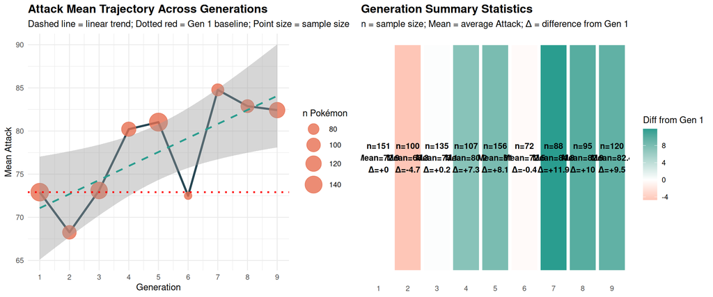

```r
grid.arrange(p3, p4, ncol = 2)
```

**Reading the Plots:**

- **Top Left (Boxplot):** Shows the full distribution of Attack for each generation. The red dashed line is the Gen 1 mean (our reference). Generations above this line have positive coefficients.
- **Top Right (Bar Chart):** These bars directly represent what the GLM estimates — the difference between each generation’s mean Attack and Gen 1. Bars above zero = higher Attack than Gen 1.
- **Bottom Left (Trajectory):** Connects the means to show the overall pattern. The upward dashed trend line suggests power creep.
- **Bottom Right (Summary):** Quick reference for sample sizes and key statistics per generation.

Now let’s fit the simple model:

```r
# Model 1: Attack as function of generation only
model1 <- glm(attack ~ gen, data = pokemon, family = gaussian(link = "identity"))

summary(model1)
```

```
##
## Call:
## glm(formula = attack ~ gen, family = gaussian(link = "identity"),
##     data = pokemon)
##
## Coefficients:
##             Estimate Std. Error t value Pr(>|t|)
## (Intercept)  72.9139     2.3965  30.425  < 2e-16 ***
## gen2         -4.6539     3.7968  -1.226  0.22058
## gen3          0.1972     3.4882   0.057  0.95493
## gen4          7.3010     3.7214   1.962  0.05004 .
## gen5          8.1181     3.3620   2.415  0.01592 *
## gen6         -0.4139     4.2177  -0.098  0.92184
## gen7         11.8588     3.9495   3.003  0.00274 **
## gen8          9.9703     3.8565   2.585  0.00987 **
## gen9          9.5111     3.6015   2.641  0.00840 **
## ---
## Signif. codes:  0 '***' 0.001 '**' 0.01 '*' 0.05 '.' 0.1 ' ' 1
##
## (Dispersion parameter for gaussian family taken to be 867.255)
##
##     Null deviance: 909432  on 1023  degrees of freedom
## Residual deviance: 880264  on 1015  degrees of freedom
## AIC: 9844.6
##
## Number of Fisher Scoring iterations: 2
```

```r
# Extract and format coefficients
model1_coefs <- tidy(model1) %>%
  mutate(
    estimate = round(estimate, 3),
    std.error = round(std.error, 3),
    statistic = round(statistic, 3),
    p.value = format.pval(p.value, digits = 3)
  )

# Generation coefficients
model1_coefs %>% filter(str_detect(term, "gen"))
```

```
## # A tibble: 8 × 5
##   term  estimate std.error statistic p.value
##   <chr>    <dbl>     <dbl>     <dbl> <chr>
## 1 gen2    -4.65       3.80    -1.23  0.22058
## 2 gen3     0.197      3.49     0.057 0.95493
## 3 gen4     7.30       3.72     1.96  0.05004
## 4 gen5     8.12       3.36     2.42  0.01592
## 5 gen6    -0.414      4.22    -0.098 0.92184
## 6 gen7    11.9        3.95     3.00  0.00274
## 7 gen8     9.97       3.86     2.58  0.00987
## 8 gen9     9.51       3.60     2.64  0.00840
```

**Interpretation:** The intercept (72.9) is the mean Attack for Generation 1. Each generation coefficient represents the difference from this baseline — exactly what we visualized in the bar chart above.

## 4.2 Model 2: With Combat Stat Controls

```r
# Model 2: Add other combat stats as controls
model2 <- glm(attack ~ gen + hp + defense + sp_attack + sp_defense + speed,
              data = pokemon, family = gaussian(link = "identity"))

summary(model2)
```

```
##
## Call:
## glm(formula = attack ~ gen + hp + defense + sp_attack + sp_defense +
##     speed, family = gaussian(link = "identity"), data = pokemon)
##
## Coefficients:
##             Estimate Std. Error t value Pr(>|t|)
## (Intercept)  7.18269    3.12015   2.302   0.0215 *
## gen2        -3.90958    2.84957  -1.372   0.1704
## gen3         1.81937    2.60626   0.698   0.4853
## gen4         2.28086    2.78560   0.819   0.4131
## gen5         5.40140    2.51079   2.151   0.0317 *
## gen6        -2.43287    3.15287  -0.772   0.4405
## gen7         7.37632    2.96078   2.491   0.0129 *
## gen8         5.12186    2.88118   1.778   0.0758 .
## gen9        -0.36887    2.70833  -0.136   0.8917
## hp           0.39163    0.02902  13.497  < 2e-16 ***
## defense      0.46333    0.02775  16.698  < 2e-16 ***
## sp_attack    0.02197    0.02935   0.749   0.4543
## sp_defense  -0.23450    0.03407  -6.882 1.03e-11 ***
## speed        0.33294    0.02681  12.421  < 2e-16 ***
## ---
## Signif. codes:  0 '***' 0.001 '**' 0.01 '*' 0.05 '.' 0.1 ' ' 1
##
## (Dispersion parameter for gaussian family taken to be 480.9793)
##
##     Null deviance: 909432  on 1023  degrees of freedom
## Residual deviance: 485789  on 1010  degrees of freedom
## AIC: 9245.9
##
## Number of Fisher Scoring iterations: 2
```

```r
model2_coefs <- tidy(model2) %>%
  mutate(
    estimate = round(estimate, 3),
    std.error = round(std.error, 3),
    statistic = round(statistic, 3),
    p.value = format.pval(p.value, digits = 3),
    significant = ifelse(as.numeric(p.value) < 0.05, "*", "")
  )

model2_coefs
```

```
## # A tibble: 14 × 6
##    term        estimate std.error statistic p.value  significant
##    <chr>          <dbl>     <dbl>     <dbl> <chr>    <chr>
##  1 (Intercept)    7.18      3.12      2.30  0.0215   "*"
##  2 gen2          -3.91      2.85     -1.37  0.1704   ""
##  3 gen3           1.82      2.61      0.698 0.4853   ""
##  4 gen4           2.28      2.79      0.819 0.4131   ""
##  5 gen5           5.40      2.51      2.15  0.0317   "*"
##  6 gen6          -2.43      3.15     -0.772 0.4405   ""
##  7 gen7           7.38      2.96      2.49  0.0129   "*"
##  8 gen8           5.12      2.88      1.78  0.0758   ""
##  9 gen9          -0.369     2.71     -0.136 0.8917   ""
## 10 hp             0.392     0.029    13.5   < 2e-16  <NA>
## 11 defense        0.463     0.028    16.7   < 2e-16  <NA>
## 12 sp_attack      0.022     0.029     0.749 0.4543   ""
## 13 sp_defense    -0.235     0.034    -6.88  1.03e-11 "*"
## 14 speed          0.333     0.027    12.4   < 2e-16  <NA>
```

## 4.3 Model 3: Full Model with All Available Predictors

```r
# Model 3: Full model with ALL available predictors
model3 <- glm(make_formula("attack", all_predictors),
              data = pokemon, family = gaussian(link = "identity"))

summary(model3)
```

```
##
## Call:
## glm(formula = make_formula("attack", all_predictors), family = gaussian(link = "identity"),
##     data = pokemon)
##
## Coefficients:
##                       Estimate Std. Error t value Pr(>|t|)
## (Intercept)          6.803e+01  3.205e+01   2.123  0.03403 *
## gen2                -2.842e+00  2.723e+00  -1.044  0.29691
## gen3                 1.421e+00  2.575e+00   0.552  0.58124
## gen4                 1.579e+00  2.721e+00   0.580  0.56177
## gen5                 4.382e+00  2.492e+00   1.758  0.07906 .
## gen6                -1.370e+00  3.182e+00  -0.431  0.66682
## gen7                 6.881e+00  2.999e+00   2.295  0.02198 *
## gen8                 6.024e+00  2.935e+00   2.053  0.04038 *
## gen9                -6.285e-01  2.938e+00  -0.214  0.83066
## hp                   2.258e-01  3.318e-02   6.805 1.79e-11 ***
## defense              3.208e-01  3.235e-02   9.915  < 2e-16 ***
## sp_attack            7.312e-02  3.218e-02   2.272  0.02330 *
## sp_defense          -2.450e-01  3.343e-02  -7.329 4.99e-13 ***
## speed                2.168e-01  2.875e-02   7.541 1.10e-13 ***
## capture_rate        -7.779e-02  1.288e-02  -6.038 2.25e-09 ***
## raritySubLegendary   3.256e+00  4.518e+00   0.721  0.47131
## rarityLegendary      1.437e+01  6.529e+00   2.200  0.02803 *
## rarityMythical       1.412e+01  6.302e+00   2.240  0.02530 *
## height_m             6.227e-01  7.220e-01   0.862  0.38868
## weight_kg            2.267e-02  8.110e-03   2.796  0.00528 **
## base_egg_steps      -2.224e-04  2.005e-04  -1.109  0.26766
## num_abilities        2.975e-01  1.099e+00   0.271  0.78660
## evo_length          -1.239e+00  4.897e-01  -2.530  0.01158 *
## has_mega_evolution1  7.145e+00  3.497e+00   2.043  0.04135 *
## has_gigantamax1      4.652e+00  3.969e+00   1.172  0.24151
## class_primary1       2.201e+01  1.187e+01   1.854  0.06402 .
## class_primary2      -5.267e+00  1.295e+01  -0.407  0.68433
## class_primary3      -5.799e+00  7.618e+00  -0.761  0.44670
## class_primary4       2.514e+00  1.237e+01   0.203  0.83894
## class_primary5       1.039e+01  1.122e+01   0.926  0.35484
## class_primary6       1.130e+01  1.100e+01   1.027  0.30468
## class_primary7       8.451e+00  1.097e+01   0.771  0.44109
## class_primary8       9.179e+00  1.485e+01   0.618  0.53680
```

[output cut: 44 more lines]

```
## against_ghost       -1.918e+00  7.596e+00  -0.253  0.80071
## against_dragon       7.278e+00  1.468e+01   0.496  0.62004
## against_dark        -7.383e+00  7.785e+00  -0.948  0.34321
## against_steel        9.163e-01  5.279e+00   0.174  0.86224
## against_fairy        4.920e+00  4.399e+00   1.118  0.26369
## ---
## Signif. codes:  0 '***' 0.001 '**' 0.01 '*' 0.05 '.' 0.1 ' ' 1
##
## (Dispersion parameter for gaussian family taken to be 381.4757)
##
##     Null deviance: 909432  on 1023  degrees of freedom
## Residual deviance: 359350  on  942  degrees of freedom
## AIC: 9073.2
##
## Number of Fisher Scoring iterations: 2
```

```r
# Extract significant predictors
model3_coefs <- tidy(model3) %>%
  mutate(significant = p.value < 0.1) %>%
  arrange(p.value)

# Show all significant predictors
model3_coefs %>%
  filter(significant) %>%
  mutate(
    estimate = round(estimate, 3),
    std.error = round(std.error, 3),
    p.value = format.pval(p.value, digits = 3)
  ) %>%
  dplyr::select(term, estimate, std.error, p.value)
```

```
## # A tibble: 20 × 4
##    term                estimate std.error p.value
##    <chr>                  <dbl>     <dbl> <chr>
##  1 defense                0.321     0.032 < 2e-16
##  2 speed                  0.217     0.029 1.10e-13
##  3 sp_defense            -0.245     0.033 4.99e-13
##  4 hp                     0.226     0.033 1.79e-11
##  5 capture_rate          -0.078     0.013 2.25e-09
##  6 against_ground        -8.53      2.75  0.00201
##  7 percent_male           0.093     0.032 0.00414
##  8 weight_kg              0.023     0.008 0.00528
##  9 evo_length            -1.24      0.49  0.01158
## 10 gen7                   6.88      3.00  0.02198
## 11 sp_attack              0.073     0.032 0.02330
## 12 rarityMythical        14.1       6.30  0.02530
## 13 rarityLegendary       14.4       6.53  0.02803
## 14 (Intercept)           68.0      32.0   0.03403
## 15 gen8                   6.02      2.94  0.04038
## 16 has_mega_evolution1    7.14      3.50  0.04135
## 17 votes_top_6            0.143     0.07  0.04197
## 18 votes_first           -0.59      0.31  0.05731
## 19 class_primary1        22.0      11.9   0.06402
## 20 gen5                   4.38      2.49  0.07906
```

## 4.4 Model 4: Gamma GLM (Robustness Check)

```r
# Model 4: Gamma GLM with log link (same predictors as Model 3)
model4 <- glm(make_formula("attack", all_predictors),
              data = pokemon, family = Gamma(link = "log"))

summary(model4)
```

```
##
## Call:
## glm(formula = make_formula("attack", all_predictors), family = Gamma(link = "log"),
##     data = pokemon)
##
## Coefficients:
##                       Estimate Std. Error t value Pr(>|t|)
## (Intercept)          3.972e+00  4.485e-01   8.857  < 2e-16 ***
## gen2                -5.110e-02  3.811e-02  -1.341 0.180366
## gen3                 6.377e-03  3.603e-02   0.177 0.859557
## gen4                 5.736e-03  3.808e-02   0.151 0.880299
## gen5                 4.679e-02  3.488e-02   1.341 0.180124
## gen6                -2.359e-02  4.453e-02  -0.530 0.596373
## gen7                 9.423e-02  4.197e-02   2.245 0.024993 *
## gen8                 6.057e-02  4.107e-02   1.475 0.140615
## gen9                -2.760e-02  4.112e-02  -0.671 0.502222
## hp                   3.088e-03  4.644e-04   6.650 4.94e-11 ***
## defense              4.786e-03  4.528e-04  10.570  < 2e-16 ***
## sp_attack            1.694e-03  4.503e-04   3.762 0.000179 ***
## sp_defense          -3.341e-03  4.678e-04  -7.142 1.84e-12 ***
## speed                2.900e-03  4.023e-04   7.208 1.17e-12 ***
## capture_rate        -1.196e-03  1.803e-04  -6.634 5.49e-11 ***
## raritySubLegendary   4.352e-02  6.323e-02   0.688 0.491423
## rarityLegendary      1.543e-01  9.137e-02   1.689 0.091532 .
## rarityMythical       2.118e-01  8.820e-02   2.402 0.016521 *
## height_m             1.598e-02  1.010e-02   1.582 0.114022
## weight_kg            1.088e-04  1.135e-04   0.959 0.337788
## base_egg_steps      -4.976e-06  2.806e-06  -1.773 0.076482 .
## num_abilities        5.944e-03  1.537e-02   0.387 0.699149
## evo_length          -2.097e-02  6.854e-03  -3.059 0.002280 **
## has_mega_evolution1  9.648e-02  4.895e-02   1.971 0.049014 *
## has_gigantamax1      5.764e-02  5.555e-02   1.038 0.299677
## class_primary1       2.831e-01  1.661e-01   1.705 0.088598 .
## class_primary2      -1.031e-01  1.813e-01  -0.569 0.569596
## class_primary3      -1.114e-01  1.066e-01  -1.045 0.296506
## class_primary4       7.754e-02  1.731e-01   0.448 0.654244
## class_primary5       1.980e-01  1.571e-01   1.261 0.207695
## class_primary6       1.695e-01  1.539e-01   1.101 0.271024
## class_primary7       1.031e-01  1.535e-01   0.672 0.501845
## class_primary8       2.203e-01  2.079e-01   1.059 0.289668
```

[output cut: 44 more lines]

```
## against_ghost        3.488e-03  1.063e-01   0.033 0.973833
## against_dragon       2.342e-01  2.054e-01   1.140 0.254532
## against_dark        -1.318e-01  1.090e-01  -1.209 0.226780
## against_steel       -2.227e-03  7.388e-02  -0.030 0.975957
## against_fairy        7.467e-02  6.157e-02   1.213 0.225515
## ---
## Signif. codes:  0 '***' 0.001 '**' 0.01 '*' 0.05 '.' 0.1 ' ' 1
##
## (Dispersion parameter for Gamma family taken to be 0.07471592)
##
##     Null deviance: 177.275  on 1023  degrees of freedom
## Residual deviance:  79.032  on  942  degrees of freedom
## AIC: 9194.5
##
## Number of Fisher Scoring iterations: 8
```

```r
# Convert coefficients to percentage change
gamma_coefs <- tidy(model4) %>%
  filter(str_detect(term, "gen")) %>%
  mutate(
    generation = as.numeric(str_extract(term, "\\d+")),
    pct_change = round((exp(estimate) - 1) * 100, 2),
    estimate = round(estimate, 4),
    p.value = format.pval(p.value, digits = 3)
  ) %>%
  dplyr::select(generation, estimate, pct_change, p.value)

gamma_coefs
```

```
## # A tibble: 10 × 4
##    generation estimate pct_change p.value
##         <dbl>    <dbl>      <dbl> <chr>
##  1          2  -0.0511      -4.98 0.1804
##  2          3   0.0064       0.64 0.8596
##  3          4   0.0057       0.58 0.8803
##  4          5   0.0468       4.79 0.1801
##  5          6  -0.0236      -2.33 0.5964
##  6          7   0.0942       9.88 0.0250
##  7          8   0.0606       6.24 0.1406
##  8          9  -0.0276      -2.72 0.5022
##  9         NA   0.0435       4.45 0.4914
## 10         NA   0.154       16.7  0.0915
```

## 4.5 Model Comparison

```r
# Compare all models
model_comparison <- data.frame(
  Model = c("M1: gen only", "M2: + combat stats", "M3: + rarity", "M4: Gamma GLM"),
  Predictors = c("gen", "gen + 5 stats", "gen + 5 stats + rarity + capture_rate",
                 "Same as M3 (Gamma)"),
  AIC = c(AIC(model1), AIC(model2), AIC(model3), AIC(model4)),
  BIC = c(BIC(model1), BIC(model2), BIC(model3), BIC(model4)),
  Deviance = c(model1$deviance, model2$deviance, model3$deviance, model4$deviance),
  Pseudo_R2 = c(
    1 - model1$deviance/model1$null.deviance,
    1 - model2$deviance/model2$null.deviance,
    1 - model3$deviance/model3$null.deviance,
    1 - model4$deviance/model4$null.deviance
  )
)

model_comparison[, 3:6] <- round(model_comparison[, 3:6], 2)

print(model_comparison, row.names = FALSE)
```

```
##               Model                            Predictors     AIC     BIC
##        M1: gen only                                   gen 9844.65 9893.96
##  M2: + combat stats                         gen + 5 stats 9245.93 9319.91
##        M3: + rarity gen + 5 stats + rarity + capture_rate 9073.22 9482.53
##       M4: Gamma GLM                    Same as M3 (Gamma) 9194.53 9603.85
##   Deviance Pseudo_R2
##  880263.86      0.03
##  485789.12      0.47
##  359350.12      0.60
##      79.03      0.55
```

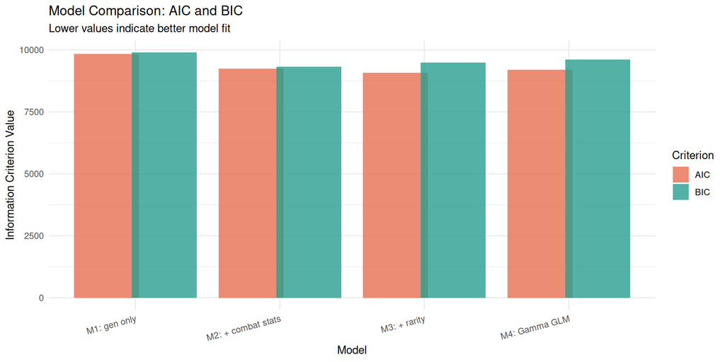

```r
# Visual comparison
model_comparison_long <- model_comparison %>%
  pivot_longer(cols = c(AIC, BIC), names_to = "Criterion", values_to = "Value")

ggplot(model_comparison_long, aes(x = Model, y = Value, fill = Criterion)) +
  geom_bar(stat = "identity", position = position_dodge(width = 0.8), alpha = 0.8) +
  scale_fill_manual(values = c("AIC" = "#E76F51", "BIC" = "#2A9D8F")) +
  labs(title = "Model Comparison: AIC and BIC",
       subtitle = "Lower values indicate better model fit",
       x = "Model", y = "Information Criterion Value") +
  theme_minimal() +
  theme(axis.text.x = element_text(angle = 15, hjust = 1))
```

## 4.6 LASSO Regularization: Feature Selection

### What is LASSO and Why Use It?

**LASSO** (Least Absolute Shrinkage and Selection Operator) is a regularization technique that adds a penalty to the regression model. This penalty forces the model to “pay a cost” for each predictor it uses. The key insight is that LASSO shrinks unimportant coefficients all the way to **exactly zero**, effectively removing them from the model.

**Why is this useful for power creep analysis?**

In standard regression (OLS/GLM), we include all 38 predictors and each gets a coefficient. But which predictors actually *matter*? LASSO answers this objectively by forcing predictors to compete:

- **Strong predictors** keep their coefficients (though slightly shrunk)
- **Weak predictors** get shrunk to zero and are eliminated
- **The λ (lambda) parameter** controls how harsh the penalty is — higher λ = fewer survivors

**The critical question:** If we force all 38 predictors to compete, does **Generation** survive? If generation coefficients shrink to zero, it means other variables (combat stats, type, rarity) explain Attack better than generation does. If generation survives, it provides unique predictive value that other variables cannot explain.

**Two common λ choices:** - **λ.min:** Minimizes cross-validation error (keeps more predictors) - **λ.1se:** One standard error rule (more parsimonious, stricter selection)

```r
# Prepare data for LASSO (requires matrix format)
# Create model matrix with all predictors (excluding intercept)
X <- model.matrix(make_formula("attack", all_predictors), data = pokemon)[, -1]
y <- pokemon$attack

cat("Feature matrix dimensions:", dim(X)[1], "observations x", dim(X)[2], "features\n")
```

```
## Feature matrix dimensions: 1024 observations x 81 features
```

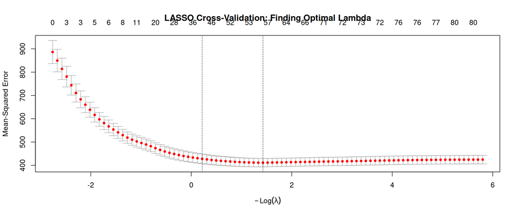

```r
# Cross-validated LASSO to find optimal lambda
set.seed(42)
cv_lasso <- cv.glmnet(X, y, alpha = 1, nfolds = 10)

# Plot cross-validation curve
plot(cv_lasso, main = "LASSO Cross-Validation: Finding Optimal Lambda")
```

```r
# Extract optimal lambdas
lambda_min <- cv_lasso$lambda.min
lambda_1se <- cv_lasso$lambda.1se

cat(paste0(
  "\n═══════════════════════════════════════════════════════════════════\n",
  "                 LASSO CROSS-VALIDATION RESULTS\n",
  "═══════════════════════════════════════════════════════════════════\n\n",
  "Lambda (min MSE):    ", round(lambda_min, 4), "\n",
  "Lambda (1-SE rule):  ", round(lambda_1se, 4), "\n",
  "  → 1-SE rule gives a more parsimonious model\n"
))
```

```
##
## ═══════════════════════════════════════════════════════════════════
##                  LASSO CROSS-VALIDATION RESULTS
## ═══════════════════════════════════════════════════════════════════
##
## Lambda (min MSE):    0.24
## Lambda (1-SE rule):  0.8044
##   → 1-SE rule gives a more parsimonious model
```

```r
# Fit final LASSO models
lasso_min <- glmnet(X, y, alpha = 1, lambda = lambda_min)
lasso_1se <- glmnet(X, y, alpha = 1, lambda = lambda_1se)

# Extract coefficients at lambda.min
coefs_min <- as.matrix(coef(lasso_min))
coefs_1se <- as.matrix(coef(lasso_1se))

# ═══════════════════════════════════════════════════════════════════
# CREATE READABLE VARIABLE NAMES (map factor levels back to names)
# ═══════════════════════════════════════════════════════════════════

# Type name lookup tables (derived from pokemon.csv mapping)
primary_type_names <- c(
  "0" = "Grass", "1" = "Fire", "2" = "Water", "3" = "Bug",
  "4" = "Normal", "5" = "Poison", "6" = "Electric", "7" = "Ground",
  "8" = "Fairy", "9" = "Fighting", "10" = "Psychic", "11" = "Rock",
  "12" = "Ghost", "13" = "Ice", "14" = "Dragon", "15" = "Dark",
  "16" = "Steel", "17" = "Flying"
)

secondary_type_names <- c(
  "0" = "Poison", "1" = "(None)", "2" = "Flying", "3" = "Dark",
  "4" = "Electric", "5" = "Ice", "6" = "Ground", "7" = "Fairy",
  "8" = "Grass", "9" = "Fighting", "10" = "Psychic", "11" = "Steel",
  "12" = "Fire", "13" = "Rock", "14" = "Water", "15" = "Dragon",
  "16" = "Ghost", "17" = "Bug", "18" = "Normal"
)

rarity_names <- c("0" = "Normal", "1" = "SubLegendary", "2" = "Legendary", "3" = "Mythical")

# Function to convert coded variable names to readable names
make_readable <- function(var_name) {
  # Generation: gen2 -> "Gen 2", gen9 -> "Gen 9"
  if(str_detect(var_name, "^gen\\d+$")) {
    return(paste0("Gen ", str_extract(var_name, "\\d+")))
  }
  # Primary type: class_primary9 -> "Type (1°): Fighting"
  if(str_detect(var_name, "^class_primary")) {
    idx <- str_extract(var_name, "\\d+")
    if(!is.na(idx) && idx %in% names(primary_type_names)) {
      return(paste0("Type (1°): ", primary_type_names[idx]))
    }
  }
  # Secondary type: class_secondary14 -> "Type (2°): Water"
  if(str_detect(var_name, "^class_secondary")) {
    idx <- str_extract(var_name, "\\d+")
    if(!is.na(idx) && idx %in% names(secondary_type_names)) {
      return(paste0("Type (2°): ", secondary_type_names[idx]))
    }
  }
  # Rarity: rarity1 -> "Rarity: SubLegendary"
  if(str_detect(var_name, "^rarity\\d+$")) {
    idx <- str_extract(var_name, "\\d+")
    if(!is.na(idx) && idx %in% names(rarity_names)) {
      return(paste0("Rarity: ", rarity_names[idx]))
    }
  }
  # Mega/Gigantamax
  if(var_name == "has_mega_evolution1") return("Has Mega Evolution")
  if(var_name == "has_gigantamax1") return("Has Gigantamax")
  # Against types: against_fire -> "vs Fire"
  if(str_detect(var_name, "^against_")) {
    type_name <- str_replace(var_name, "against_", "")
    return(paste0("vs ", str_to_title(type_name)))
  }
  # Default: return as-is but with nicer formatting
  return(str_to_title(str_replace_all(var_name, "_", " ")))
}

# Create coefficient dataframe with readable names
lasso_coefs <- data.frame(
  Variable_Code = rownames(coefs_min),
  Coef_LambdaMin = round(as.vector(coefs_min), 4),
  Coef_Lambda1SE = round(as.vector(coefs_1se), 4)
) %>%
  filter(Variable_Code != "(Intercept)") %>%
  mutate(
    Variable = sapply(Variable_Code, make_readable),
    Selected_Min = Coef_LambdaMin != 0,
    Selected_1SE = Coef_Lambda1SE != 0
  ) %>%
  arrange(desc(abs(Coef_LambdaMin)))

# Summary statistics
n_selected_min <- sum(lasso_coefs$Selected_Min)
n_selected_1se <- sum(lasso_coefs$Selected_1SE)
n_total <- nrow(lasso_coefs)

cat(paste0(
  "\n═══════════════════════════════════════════════════════════════════\n",
  "                 FEATURE SELECTION SUMMARY\n",
  "═══════════════════════════════════════════════════════════════════\n\n",
  "Total features:              ", n_total, "\n",
  "Selected (lambda.min):       ", n_selected_min, " (", round(100*n_selected_min/n_total, 1), "%)\n",
  "Selected (lambda.1se):       ", n_selected_1se, " (", round(100*n_selected_1se/n_total, 1), "%)\n",
  "\n--- Top 15 Features (by |coefficient| at lambda.min) ---\n"
))
```

```
##
## ═══════════════════════════════════════════════════════════════════
##                  FEATURE SELECTION SUMMARY
## ═══════════════════════════════════════════════════════════════════
##
## Total features:              81
## Selected (lambda.min):       53 (65.4%)
## Selected (lambda.1se):       41 (50.6%)
##
## --- Top 15 Features (by |coefficient| at lambda.min) ---
```

```r
print(head(lasso_coefs %>%
             filter(Selected_Min) %>%
             arrange(desc(abs(Coef_LambdaMin))) %>%
             dplyr::select(Variable, Coef_LambdaMin, Selected_1SE), 15),
      row.names = FALSE)
```

```
##             Variable Coef_LambdaMin Selected_1SE
##    Type (2°): Dragon       -11.2112         TRUE
##      Raritylegendary         9.5387         TRUE
##      Type (1°): Fire         8.4579         TRUE
##  Type (1°): Fighting         7.7318         TRUE
##       Raritymythical         7.5567         TRUE
##      Type (2°): Dark         7.4681         TRUE
##              vs Dark        -7.3611         TRUE
##     Type (2°): Ghost         7.1109         TRUE
##   Has Mega Evolution         6.8968         TRUE
##    Type (1°): Dragon         5.5472         TRUE
##            vs Poison        -5.4875         TRUE
##                Gen 7         5.0028         TRUE
##    Type (2°): Ground        -4.7797        FALSE
##                Gen 8         3.9143         TRUE
##                Gen 5         3.8903         TRUE
```

```r
# Also show top features at lambda.1se (stricter selection)
lasso_coefs_1se <- lasso_coefs %>%
  filter(Selected_1SE) %>%
  arrange(desc(abs(Coef_Lambda1SE)))

cat(paste0(
  "\n--- Top 15 Features (by |coefficient| at lambda.1se - stricter) ---\n"
))
```

```
##
## --- Top 15 Features (by |coefficient| at lambda.1se - stricter) ---
```

```r
print(head(lasso_coefs_1se %>%
             dplyr::select(Variable, Coef_Lambda1SE), 15),
      row.names = FALSE)
```

```
##             Variable Coef_Lambda1SE
##  Type (1°): Fighting        12.2654
##  Type (2°): Fighting         7.5295
##    Type (2°): Dragon        -6.0904
##      Type (2°): Dark         5.7469
##    Type (1°): Ground         5.2959
##   Has Mega Evolution         5.0991
##              vs Dark        -4.2903
##     Type (2°): Ghost         4.0616
##   Type (1°): Psychic        -3.9437
##     Type (2°): Fairy        -3.5043
##                Gen 2        -3.3283
##      Raritylegendary         3.1983
##    Type (1°): Dragon         3.1599
##                Gen 5         2.5716
##             vs Fairy         2.1926
```

```r
# Show the mapping for reference
cat(paste0(
  "\n--- Variable Name Key ---\n",
  "Type (1°) = Primary Type | Type (2°) = Secondary Type\n",
  "vs [Type] = Damage multiplier against that type\n",
  "Gen X = Generation X (vs Gen 1 baseline)\n"
))
```

```
##
## --- Variable Name Key ---
## Type (1°) = Primary Type | Type (2°) = Secondary Type
## vs [Type] = Damage multiplier against that type
## Gen X = Generation X (vs Gen 1 baseline)
```

```r
# KEY QUESTION: Does Generation survive LASSO?
gen_vars <- lasso_coefs %>% filter(str_detect(Variable_Code, "^gen"))

cat(paste0(
  "\n═══════════════════════════════════════════════════════════════════\n",
  "       CRITICAL: DOES GENERATION SURVIVE FEATURE SELECTION?\n",
  "═══════════════════════════════════════════════════════════════════\n\n",
  "Generation coefficients in LASSO:\n\n"
))
```

```
##
## ═══════════════════════════════════════════════════════════════════
##        CRITICAL: DOES GENERATION SURVIVE FEATURE SELECTION?
## ═══════════════════════════════════════════════════════════════════
##
## Generation coefficients in LASSO:
```

```r
print(gen_vars %>% dplyr::select(Variable, Coef_LambdaMin, Coef_Lambda1SE, Selected_Min, Selected_1SE),
      row.names = FALSE)
```

```
##  Variable Coef_LambdaMin Coef_Lambda1SE Selected_Min Selected_1SE
##     Gen 7         5.0028         2.1511         TRUE         TRUE
##     Gen 8         3.9143         1.2158         TRUE         TRUE
##     Gen 5         3.8903         2.5716         TRUE         TRUE
##     Gen 2        -3.4922        -3.3283         TRUE         TRUE
##     Gen 6        -1.4761        -0.0049         TRUE         TRUE
##     Gen 9        -0.2120         0.0000         TRUE        FALSE
##     Gen 3         0.0000         0.0000        FALSE        FALSE
##     Gen 4         0.0000         0.0000        FALSE        FALSE
```

```r
n_gen_min <- sum(gen_vars$Selected_Min)
n_gen_1se <- sum(gen_vars$Selected_1SE)

if(n_gen_1se > 0) {
  cat(paste0(
    "\n--- Summary ---\n",
    "Generation levels retained (lambda.min): ", n_gen_min, " / 8\n",
    "Generation levels retained (lambda.1se): ", n_gen_1se, " / 8\n\n",
    "✓ GENERATION SURVIVES feature selection!\n",
    "  → ", n_gen_1se, " generation level(s) have non-zero effect even in sparse model\n",
    "  → This supports the power creep hypothesis\n"
  ))
} else if(n_gen_min > 0) {
  cat(paste0(
    "\n--- Summary ---\n",
    "Generation levels retained (lambda.min): ", n_gen_min, " / 8\n",
    "Generation levels retained (lambda.1se): ", n_gen_1se, " / 8\n\n",
    "⚠ GENERATION is marginally important\n",
    "  → Retained at lambda.min but dropped at lambda.1se\n",
    "  → Effect exists but is weaker than other predictors\n"
  ))
} else {
  cat(paste0(
    "\n--- Summary ---\n",
    "Generation levels retained (lambda.min): ", n_gen_min, " / 8\n",
    "Generation levels retained (lambda.1se): ", n_gen_1se, " / 8\n\n",
    "✗ GENERATION does NOT survive feature selection\n",
    "  → All generation coefficients shrunk to zero\n",
    "  → Other predictors explain Attack better than generation\n"
  ))
}
```

```
##
## --- Summary ---
## Generation levels retained (lambda.min): 6 / 8
## Generation levels retained (lambda.1se): 5 / 8
##
## ✓ GENERATION SURVIVES feature selection!
##   → 5 generation level(s) have non-zero effect even in sparse model
##   → This supports the power creep hypothesis
```

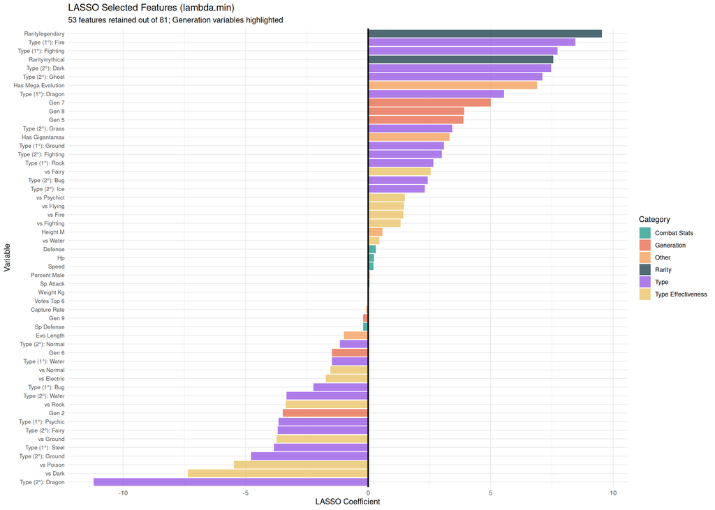

```r
# Visualize non-zero coefficients with readable names
lasso_nonzero <- lasso_coefs %>%
  filter(Selected_Min) %>%
  mutate(
    is_gen = str_detect(Variable_Code, "^gen"),
    Category = case_when(
      str_detect(Variable_Code, "^gen") ~ "Generation",
      str_detect(Variable_Code, "^against") ~ "Type Effectiveness",
      str_detect(Variable_Code, "^class") ~ "Type",
      Variable_Code %in% c("hp", "defense", "sp_attack", "sp_defense", "speed") ~ "Combat Stats",
      str_detect(Variable_Code, "^rarity") ~ "Rarity",
      TRUE ~ "Other"
    )
  )

ggplot(lasso_nonzero, aes(x = reorder(Variable, Coef_LambdaMin),
                           y = Coef_LambdaMin, fill = Category)) +
  geom_bar(stat = "identity", alpha = 0.8) +
  geom_hline(yintercept = 0, color = "black", linewidth = 1) +
  coord_flip() +
  scale_fill_manual(values = c(
    "Generation" = "#E76F51",
    "Combat Stats" = "#2A9D8F",
    "Type Effectiveness" = "#E9C46A",
    "Type" = "#9B5DE5",
    "Rarity" = "#264653",
    "Other" = "#F4A261"
  )) +
  labs(title = "LASSO Selected Features (lambda.min)",
       subtitle = paste0(n_selected_min, " features retained out of ", n_total,
                        "; Generation variables highlighted"),
       x = "Variable", y = "LASSO Coefficient") +
  theme_minimal() +
  theme(axis.text.y = element_text(size = 8),
        legend.position = "right")
```

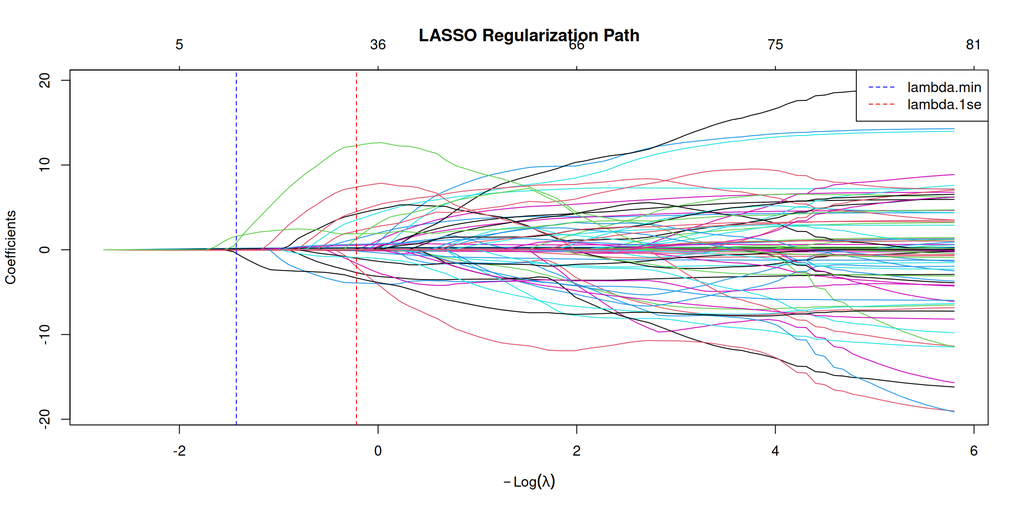

```r
# Plot regularization path
lasso_full <- glmnet(X, y, alpha = 1)

# Extract generation variable indices
gen_indices <- which(str_detect(colnames(X), "^gen"))

# Custom plot with generation highlighted
plot(lasso_full, xvar = "lambda", label = FALSE,
     main = "LASSO Regularization Path")
abline(v = log(lambda_min), lty = 2, col = "blue")
abline(v = log(lambda_1se), lty = 2, col = "red")
legend("topright", legend = c("lambda.min", "lambda.1se"),
       lty = 2, col = c("blue", "red"))
```

```r
# Create importance ranking
importance_df <- lasso_coefs %>%
  filter(Selected_Min) %>%
  mutate(
    Abs_Coef = abs(Coef_LambdaMin),
    Rank = rank(-Abs_Coef)
  ) %>%
  arrange(Rank) %>%
  head(20)

cat(paste0(
  "\n═══════════════════════════════════════════════════════════════════\n",
  "              TOP 20 MOST IMPORTANT PREDICTORS (LASSO)\n",
  "═══════════════════════════════════════════════════════════════════\n\n"
))
```

```
##
## ═══════════════════════════════════════════════════════════════════
##               TOP 20 MOST IMPORTANT PREDICTORS (LASSO)
## ═══════════════════════════════════════════════════════════════════
```

```r
print(importance_df %>% dplyr::select(Rank, Variable, Coef_LambdaMin), row.names = FALSE)
```

```
##  Rank            Variable Coef_LambdaMin
##     1   Type (2°): Dragon       -11.2112
##     2     Raritylegendary         9.5387
##     3     Type (1°): Fire         8.4579
##     4 Type (1°): Fighting         7.7318
##     5      Raritymythical         7.5567
##     6     Type (2°): Dark         7.4681
##     7             vs Dark        -7.3611
##     8    Type (2°): Ghost         7.1109
##     9  Has Mega Evolution         6.8968
##    10   Type (1°): Dragon         5.5472
##    11           vs Poison        -5.4875
##    12               Gen 7         5.0028
##    13   Type (2°): Ground        -4.7797
##    14               Gen 8         3.9143
##    15               Gen 5         3.8903
##    16    Type (1°): Steel        -3.8482
##    17           vs Ground        -3.7338
##    18    Type (2°): Fairy        -3.6964
##    19  Type (1°): Psychic        -3.6632
##    20               Gen 2        -3.4922
```

```r
# Find where generation ranks
gen_ranks <- importance_df %>%
  filter(str_detect(Variable_Code, "^gen")) %>%
  pull(Rank)

if(length(gen_ranks) > 0) {
  cat(paste0("\n→ Generation variables rank: ", paste(gen_ranks, collapse = ", "),
      " out of ", n_selected_min, " selected features\n"))
}
```

```
##
## → Generation variables rank: 12, 14, 15, 20 out of 53 selected features
```

# 5. Hypothesis Testing: Generation Effect

## 5.1 Likelihood Ratio Test

```r
# Null model (without generation) - same predictors as model3 minus gen
model_null <- glm(make_formula("attack", predictors_no_gen),
                  data = pokemon, family = gaussian(link = "identity"))

# LR test: Does generation matter?
lr_test <- anova(model_null, model3, test = "Chisq")

print(lr_test)
```

```
## Analysis of Deviance Table
##
## Model 1: attack ~ hp + defense + sp_attack + sp_defense + speed + capture_rate +
##     rarity + height_m + weight_kg + base_egg_steps + num_abilities +
##     evo_length + has_mega_evolution + has_gigantamax + class_primary +
##     class_secondary + percent_male + percent_female + votes_first +
##     votes_top_6 + against_normal + against_fire + against_water +
##     against_electric + against_grass + against_ice + against_fighting +
##     against_poison + against_ground + against_flying + against_psychict +
##     against_bug + against_rock + against_ghost + against_dragon +
##     against_dark + against_steel + against_fairy
## Model 2: attack ~ gen + hp + defense + sp_attack + sp_defense + speed +
##     capture_rate + rarity + height_m + weight_kg + base_egg_steps +
##     num_abilities + evo_length + has_mega_evolution + has_gigantamax +
##     class_primary + class_secondary + percent_male + percent_female +
##     votes_first + votes_top_6 + against_normal + against_fire +
##     against_water + against_electric + against_grass + against_ice +
##     against_fighting + against_poison + against_ground + against_flying +
##     against_psychict + against_bug + against_rock + against_ghost +
##     against_dragon + against_dark + against_steel + against_fairy
##   Resid. Df Resid. Dev Df Deviance Pr(>Chi)
## 1       950     366878
## 2       942     359350  8     7528  0.01139 *
## ---
## Signif. codes:  0 '***' 0.001 '**' 0.01 '*' 0.05 '.' 0.1 ' ' 1
```

```r
lr_p <- lr_test$`Pr(>Chi)`[2]
```

## 5.2 ANOVA Type III

```r
# Type III ANOVA to assess each predictor's contribution
# Use lm instead of glm for proper ANOVA with Sum of Squares
model3_lm <- lm(make_formula("attack", all_predictors), data = pokemon)
anova_results <- Anova(model3_lm, type = "III")

print(anova_results)
```

```
## Anova Table (Type III tests)
##
## Response: attack
##                    Sum Sq  Df F value    Pr(>F)
## (Intercept)          1719   1  4.5063  0.034031 *
## gen                  7528   8  2.4667  0.011995 *
## hp                  17666   1 46.3095 1.794e-11 ***
## defense             37502   1 98.3084 < 2.2e-16 ***
## sp_attack            1970   1  5.1629  0.023299 *
## sp_defense          20490   1 53.7115 4.991e-13 ***
## speed               21691   1 56.8609 1.099e-13 ***
## capture_rate        13907   1 36.4546 2.246e-09 ***
## rarity               3052   3  2.6672  0.046594 *
## height_m              284   1  0.7437  0.388684
## weight_kg            2982   1  7.8176  0.005279 **
## base_egg_steps        469   1  1.2301  0.267662
## num_abilities          28   1  0.0733  0.786598
## evo_length           2441   1  6.3986  0.011583 *
## has_mega_evolution   1592   1  4.1732  0.041346 *
## has_gigantamax        524   1  1.3735  0.241513
## class_primary        6837  17  1.0543  0.395472
## class_secondary      7150  18  1.0412  0.409578
## percent_male         3152   1  8.2639  0.004135 **
## percent_female          0   1  0.0000  0.997679
## votes_first          1382   1  3.6224  0.057312 .
## votes_top_6          1582   1  4.1478  0.041967 *
## against_normal        527   1  1.3817  0.240117
## against_fire          251   1  0.6583  0.417373
## against_water           2   1  0.0056  0.940434
## against_electric        0   1  0.0012  0.972407
## against_grass         513   1  1.3450  0.246446
## against_ice           342   1  0.8973  0.343762
## against_fighting       78   1  0.2035  0.651980
## against_poison        555   1  1.4544  0.228134
## against_ground       3661   1  9.5977  0.002006 **
## against_flying        882   1  2.3122  0.128697
## against_psychict      192   1  0.5025  0.478563
## against_bug            34   1  0.0887  0.765915
## against_rock          941   1  2.4663  0.116646
## against_ghost          24   1  0.0638  0.800706
## against_dragon         94   1  0.2460  0.620042
## against_dark          343   1  0.8993  0.343213
## against_steel          11   1  0.0301  0.862244
## against_fairy         477   1  1.2508  0.263694
## Residuals          359350 942
## ---
## Signif. codes:  0 '***' 0.001 '**' 0.01 '*' 0.05 '.' 0.1 ' ' 1
```

```r
# Calculate partial eta-squared
# Get the residual SS (last row)
residual_ss <- anova_results$`Sum Sq`[nrow(anova_results)]

eta_sq <- data.frame(
  Predictor = rownames(anova_results),
  SS = anova_results$`Sum Sq`
) %>%
  filter(Predictor != "Residuals") %>%
  mutate(
    Partial_Eta_Sq = SS / (SS + residual_ss)
  ) %>%
  arrange(desc(Partial_Eta_Sq)) %>%
  mutate(across(where(is.numeric), ~round(., 4)))

eta_sq
```

```
##             Predictor         SS Partial_Eta_Sq
## 1             defense 37502.2836         0.0945
## 2               speed 21691.0552         0.0569
## 3          sp_defense 20489.6345         0.0539
## 4                  hp 17665.9337         0.0469
## 5        capture_rate 13906.5623         0.0373
## 6                 gen  7527.9895         0.0205
## 7     class_secondary  7149.5279         0.0195
## 8       class_primary  6837.1205         0.0187
## 9      against_ground  3661.2821         0.0101
## 10       percent_male  3152.4607         0.0087
## 11             rarity  3052.4054         0.0084
## 12          weight_kg  2982.2233         0.0082
## 13         evo_length  2440.9110         0.0067
## 14          sp_attack  1969.5297         0.0055
```

[output cut: 26 more lines]

## 5.3 Jonckheere-Terpstra Test for Monotonic Trend

The Jonckheere-Terpstra test specifically tests for an **ordered alternative hypothesis** — whether Attack systematically increases (or decreases) across generations. This is more powerful than ANOVA when we expect a directional “creep.”

```r
# Jonckheere-Terpstra test for monotonic trend
# H0: No trend across ordered groups
# H1: Monotonic increasing (or decreasing) trend

# Prepare data - ensure generation is ordered
pokemon_ordered <- pokemon %>%
  arrange(gen_numeric)

# Perform Jonckheere-Terpstra test
jt_result <- JonckheereTerpstraTest(
  x = pokemon_ordered$attack,
  g = pokemon_ordered$gen_numeric,
  alternative = "increasing"  # Test for increasing trend (power creep)
)

if(jt_result$p.value < 0.05) {
  conclusion <- paste0(
    "✓ SIGNIFICANT MONOTONIC TREND DETECTED (p < 0.05)\n",
    "  → Attack values show a systematic increase across generations\n",
    "  → This directly supports the 'power creep' hypothesis\n"
  )
} else if(jt_result$p.value < 0.10) {
  conclusion <- paste0(
    "⚠ MARGINALLY SIGNIFICANT TREND (0.05 < p < 0.10)\n",
    "  → Weak evidence for increasing trend\n"
  )
} else {
  conclusion <- paste0(
    "✗ NO SIGNIFICANT MONOTONIC TREND (p ≥ 0.10)\n",
    "  → Attack does not systematically increase across generations\n"
  )
}

cat(paste0(
  "\n═══════════════════════════════════════════════════════════════════\n",
  "         JONCKHEERE-TERPSTRA TEST FOR MONOTONIC TREND\n",
  "═══════════════════════════════════════════════════════════════════\n\n",
  "Test Hypothesis:\n",
  "  H₀: Attack distribution is the same across all generations\n",
  "  H₁: Attack shows a monotonic INCREASING trend (Gen 1 → Gen 9)\n\n",
  "Results:\n",
  "  JT Statistic:  ", jt_result$statistic, "\n",
  "  p-value:       ", format.pval(jt_result$p.value, digits = 4), "\n",
  "  Alternative:   ", jt_result$alternative, "\n\n",
  conclusion
))
```

```
##
## ═══════════════════════════════════════════════════════════════════
##          JONCKHEERE-TERPSTRA TEST FOR MONOTONIC TREND
## ═══════════════════════════════════════════════════════════════════
##
## Test Hypothesis:
##   H₀: Attack distribution is the same across all generations
##   H₁: Attack shows a monotonic INCREASING trend (Gen 1 → Gen 9)
##
## Results:
##   JT Statistic:  253582.5
##   p-value:       2.088e-05
##   Alternative:   increasing
##
## ✓ SIGNIFICANT MONOTONIC TREND DETECTED (p < 0.05)
##   → Attack values show a systematic increase across generations
##   → This directly supports the 'power creep' hypothesis
```

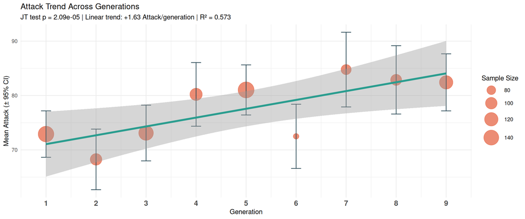

```r
# Visualize the trend with regression line
gen_means_ordered <- pokemon %>%
  group_by(gen_numeric) %>%
  summarise(
    mean_attack = mean(attack),
    se = sd(attack) / sqrt(n()),
    n = n()
  )

# Linear trend
trend_model <- lm(mean_attack ~ gen_numeric, data = gen_means_ordered)
trend_coef <- coef(trend_model)[2]
trend_r2 <- summary(trend_model)$r.squared

ggplot(gen_means_ordered, aes(x = gen_numeric, y = mean_attack)) +
  geom_point(aes(size = n), color = "#E76F51", alpha = 0.8) +
  geom_errorbar(aes(ymin = mean_attack - 1.96*se, ymax = mean_attack + 1.96*se),
                width = 0.2, color = "#264653") +
  geom_smooth(method = "lm", se = TRUE, color = "#2A9D8F", linewidth = 1.5) +
  scale_size_continuous(range = c(4, 12), name = "Sample Size") +
  scale_x_continuous(breaks = 1:9) +
  labs(title = "Attack Trend Across Generations",
       subtitle = paste0("JT test p = ", format.pval(jt_result$p.value, digits = 3),
                        " | Linear trend: +", round(trend_coef, 2), " Attack/generation",
                        " | R² = ", round(trend_r2, 3)),
       x = "Generation", y = "Mean Attack (± 95% CI)") +
  theme_minimal() +
  theme(axis.text.x = element_text(size = 12, face = "bold"))
```

```r
# Also test two-sided for completeness
jt_twosided <- JonckheereTerpstraTest(
  x = pokemon_ordered$attack,
  g = pokemon_ordered$gen_numeric,
  alternative = "two.sided"
)

# Summary table
jt_summary <- data.frame(
  Test = c("One-sided (increasing)", "Two-sided"),
  JT_Statistic = c(jt_result$statistic, jt_twosided$statistic),
  p_value = c(jt_result$p.value, jt_twosided$p.value),
  Conclusion = c(
    ifelse(jt_result$p.value < 0.05, "Significant ✓", "Not significant"),
    ifelse(jt_twosided$p.value < 0.05, "Significant ✓", "Not significant")
  )
)
jt_summary$p_value <- format.pval(jt_summary$p_value, digits = 4)
print(jt_summary, row.names = FALSE)
```

```
##                    Test JT_Statistic   p_value    Conclusion
##  One-sided (increasing)     253582.5 2.088e-05 Significant ✓
##               Two-sided     253582.5 4.177e-05 Significant ✓
```

## 5.4 Generation Coefficients Visualization

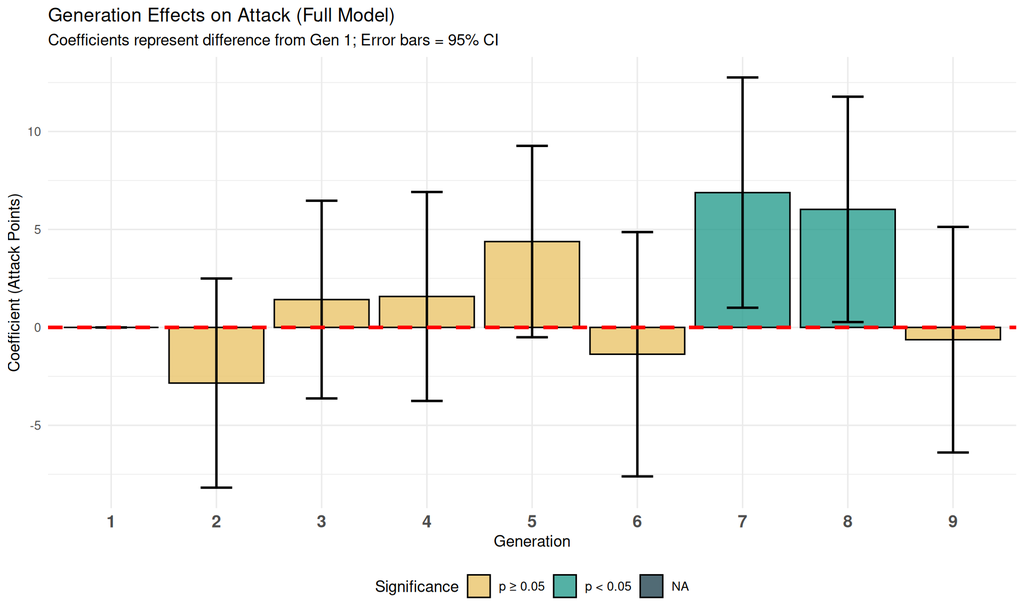

```r
# Extract generation coefficients from full model
gen_coefs <- tidy(model3) %>%
  filter(str_detect(term, "^gen")) %>%
  mutate(
    generation = as.numeric(str_extract(term, "\\d+")),
    ci_lower = estimate - 1.96 * std.error,
    ci_upper = estimate + 1.96 * std.error,
    significant = p.value < 0.05
  )

# Add Gen 1 reference
gen_coefs_plot <- bind_rows(
  data.frame(term = "gen1", estimate = 0, std.error = 0, statistic = NA,
             p.value = NA, generation = 1, ci_lower = 0, ci_upper = 0,
             significant = NA),
  gen_coefs
)

ggplot(gen_coefs_plot, aes(x = factor(generation), y = estimate, fill = significant)) +
  geom_bar(stat = "identity", alpha = 0.8, color = "black") +
  geom_errorbar(aes(ymin = ci_lower, ymax = ci_upper), width = 0.3, linewidth = 0.8) +
  geom_hline(yintercept = 0, linetype = "dashed", color = "red", linewidth = 1.2) +
  scale_fill_manual(values = c("TRUE" = "#2A9D8F", "FALSE" = "#E9C46A"),
                    na.value = "#264653",
                    labels = c("TRUE" = "p < 0.05", "FALSE" = "p ≥ 0.05"),
                    na.translate = TRUE) +
  labs(title = "Generation Effects on Attack (Full Model)",
       subtitle = "Coefficients represent difference from Gen 1; Error bars = 95% CI",
       x = "Generation", y = "Coefficient (Attack Points)",
       fill = "Significance") +
  theme_minimal() +
  theme(legend.position = "bottom",
        axis.text.x = element_text(size = 12, face = "bold"))
```

# 6. Robustness Checks

## 6.1 Robust Regression (Huber M-estimation)

```r
# Robust regression using Huber M-estimation (full model)
model_robust <- rlm(make_formula("attack", all_predictors),
                    data = pokemon, method = "M")

# Compare OLS vs Robust coefficients
ols_coefs <- coef(model3)
robust_coefs <- coef(model_robust)

comparison <- data.frame(
  Term = names(ols_coefs),
  OLS = round(ols_coefs, 3),
  Robust = round(robust_coefs, 3),
  Difference = round(ols_coefs - robust_coefs, 3),
  Pct_Diff = round(100 * (ols_coefs - robust_coefs) / abs(ols_coefs), 1)
) %>%
  filter(str_detect(Term, "^gen"))

print(comparison, row.names = FALSE)
```

```
##  Term    OLS Robust Difference Pct_Diff
##  gen2 -2.842 -2.750     -0.093     -3.3
##  gen3  1.421 -0.801      2.221    156.4
##  gen4  1.579 -0.844      2.424    153.5
##  gen5  4.382  3.718      0.663     15.1
##  gen6 -1.370 -2.454      1.084     79.1
##  gen7  6.881  5.504      1.377     20.0
##  gen8  6.024  4.984      1.040     17.3
##  gen9 -0.628 -2.139      1.511    240.4
```

```r
max_pct_diff <- max(abs(comparison$Pct_Diff), na.rm = TRUE)
```

## 6.2 Robustness Comparison Plot

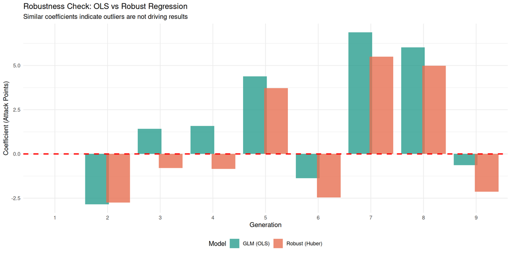

```r
# Compare OLS vs Robust regression
robustness_data <- bind_rows(
  gen_coefs %>%
    dplyr::select(generation, estimate) %>%
    mutate(Model = "GLM (OLS)"),
  data.frame(generation = 2:9, estimate = robust_coefs[grep("^gen", names(robust_coefs))],
             Model = "Robust (Huber)")
)

# Add Gen 1 reference
robustness_data <- bind_rows(
  data.frame(generation = 1, estimate = 0, Model = c("GLM (OLS)", "Robust (Huber)")),
  robustness_data
)

ggplot(robustness_data, aes(x = factor(generation), y = estimate, fill = Model)) +
  geom_bar(stat = "identity", position = position_dodge(width = 0.8), alpha = 0.8) +
  geom_hline(yintercept = 0, linetype = "dashed", color = "red", linewidth = 1) +
  scale_fill_manual(values = c("GLM (OLS)" = "#2A9D8F", "Robust (Huber)" = "#E76F51")) +
  labs(title = "Robustness Check: OLS vs Robust Regression",
       subtitle = "Similar coefficients indicate outliers are not driving results",
       x = "Generation", y = "Coefficient (Attack Points)") +
  theme_minimal() +
  theme(legend.position = "bottom")
```

# 7. Secondary Analyses: Subgroup Trends

## 7.1 Type-Specific Power Creep Analysis

Do all Pokémon types experience equal power creep, or are some types driving the trend?

```r
# Calculate mean Attack by Type and Generation (type_name already created in preprocessing)
type_gen_trends <- pokemon %>%
  group_by(type_name, gen_numeric) %>%
  summarise(
    n = n(),
    mean_attack = mean(attack),
    sd_attack = sd(attack),
    se = sd(attack) / sqrt(n()),
    .groups = "drop"
  )

# Count types and their coverage across generations
type_coverage <- type_gen_trends %>%
  group_by(type_name) %>%
  summarise(
    n_gens = n_distinct(gen_numeric),
    total_n = sum(n)
  ) %>%
  arrange(desc(total_n))

cat("All types and their data coverage:\n")
```

```
## All types and their data coverage:
```

```r
print(type_coverage, n = Inf)
```

```
## # A tibble: 18 × 3
##    type_name n_gens total_n
##    <chr>      <int>   <int>
##  1 Water          9     134
##  2 Normal         9     117
##  3 Grass          9     103
##  4 Bug            9      83
##  5 Fire           9      66
##  6 Psychic        9      60
##  7 Electric       9      59
##  8 Rock           9      58
##  9 Dark           8      45
## 10 Poison         9      42
## 11 Fighting       9      40
## 12 Ground         8      40
## 13 Dragon         8      37
## 14 Steel          8      36
## 15 Ghost          9      35
## 16 Ice            8      31
## 17 Fairy          7      29
## 18 Flying         4       9
```

```r
# Fit linear trend for each type (all types included)
type_trends <- pokemon %>%
  group_by(type_name) %>%
  do({
    model <- lm(attack ~ gen_numeric, data = .)
    data.frame(
      slope = coef(model)[2],
      intercept = coef(model)[1],
      p_value = summary(model)$coefficients[2, 4],
      r_squared = summary(model)$r.squared,
      n = nrow(.)
    )
  }) %>%
  ungroup() %>%
  mutate(
    significant = p_value < 0.05,
    direction = case_when(
      slope > 0 & significant ~ "Increasing ↑",
      slope < 0 & significant ~ "Decreasing ↓",
      TRUE ~ "No trend"
    )
  ) %>%
  arrange(desc(slope))

cat(paste0(
  "\n═══════════════════════════════════════════════════════════════════\n",
  "              TYPE-SPECIFIC ATTACK TRENDS\n",
  "═══════════════════════════════════════════════════════════════════\n\n",
  "Trend = Change in Attack per generation (slope of linear regression)\n\n"
))
```

```
##
## ═══════════════════════════════════════════════════════════════════
##               TYPE-SPECIFIC ATTACK TRENDS
## ═══════════════════════════════════════════════════════════════════
##
## Trend = Change in Attack per generation (slope of linear regression)
```

```r
print(type_trends %>%
        mutate(across(c(slope, intercept, r_squared), ~round(., 3)),
               p_value = format.pval(p_value, digits = 3)) %>%
        dplyr::select(type_name, slope, p_value, direction, n),
      n = Inf)
```

```
## # A tibble: 18 × 5
##    type_name  slope p_value direction        n
##    <chr>      <dbl> <chr>   <chr>        <int>
##  1 Flying     4.47  0.5761  No trend         9
##  2 Fighting   4.05  0.0108  Increasing ↑    40
##  3 Ice        3.40  0.1153  No trend        31
##  4 Fairy      2.70  0.2095  No trend        29
##  5 Electric   2.24  0.0580  No trend        59
##  6 Normal     2.00  0.0675  No trend       117
##  7 Grass      1.83  0.0888  No trend       103
##  8 Ground     1.63  0.3626  No trend        40
##  9 Bug        1.39  0.3564  No trend        83
## 10 Dark       1.31  0.4488  No trend        45
## 11 Steel      1.28  0.4825  No trend        36
## 12 Water      1.18  0.1692  No trend       134
## 13 Ghost      1.12  0.5525  No trend        35
## 14 Poison     0.496 0.6325  No trend        42
## 15 Psychic    0.403 0.8278  No trend        60
## 16 Fire      -0.228 0.8456  No trend        66
## 17 Rock      -0.38  0.8156  No trend        58
## 18 Dragon    -0.956 0.6427  No trend        37
```

```r
# Summary
n_increasing <- sum(type_trends$direction == "Increasing ↑")
n_decreasing <- sum(type_trends$direction == "Decreasing ↓")
n_none <- sum(type_trends$direction == "No trend")

cat(paste0(
  "\n--- Summary ---\n",
  "Types with significant INCREASING trend: ", n_increasing, "\n",
  "Types with significant DECREASING trend: ", n_decreasing, "\n",
  "Types with NO significant trend:         ", n_none, "\n"
))
```

```
##
## --- Summary ---
## Types with significant INCREASING trend: 1
## Types with significant DECREASING trend: 0
## Types with NO significant trend:         17
```

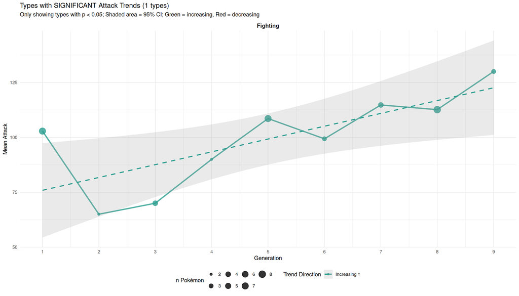

```r
# Plot trends for SIGNIFICANT types only
significant_types <- type_trends %>%
  filter(direction != "No trend") %>%
  pull(type_name)

n_sig <- length(significant_types)

if(n_sig > 0) {
  type_plot_data <- pokemon %>%
    filter(type_name %in% significant_types) %>%
    group_by(type_name, gen_numeric) %>%
    summarise(mean_attack = mean(attack), n = n(), .groups = "drop") %>%
    # Add direction info for coloring
    left_join(type_trends %>% dplyr::select(type_name, direction, slope, p_value), by = "type_name")

  ggplot(type_plot_data, aes(x = gen_numeric, y = mean_attack, color = direction)) +
    geom_line(linewidth = 1.2, alpha = 0.8) +
    geom_point(aes(size = n), alpha = 0.8) +
    geom_smooth(method = "lm", se = TRUE, linetype = "dashed", linewidth = 1, alpha = 0.2) +
    scale_x_continuous(breaks = 1:9) +
    scale_size_continuous(range = c(2, 6), name = "n Pokémon") +
    scale_color_manual(values = c("Increasing ↑" = "#2A9D8F", "Decreasing ↓" = "#E76F51"),
                       name = "Trend Direction") +
    facet_wrap(~type_name, ncol = 3, scales = "free_y") +
    labs(title = paste0("Types with SIGNIFICANT Attack Trends (", n_sig, " types)"),
         subtitle = "Only showing types with p < 0.05; Shaded area = 95% CI; Green = increasing, Red = decreasing",
         x = "Generation", y = "Mean Attack") +
    theme_minimal() +
    theme(legend.position = "bottom",
          strip.text = element_text(face = "bold", size = 11),
          axis.text.x = element_text(size = 9))
} else {
  cat("No types show statistically significant trends at p < 0.05\n")
}
```

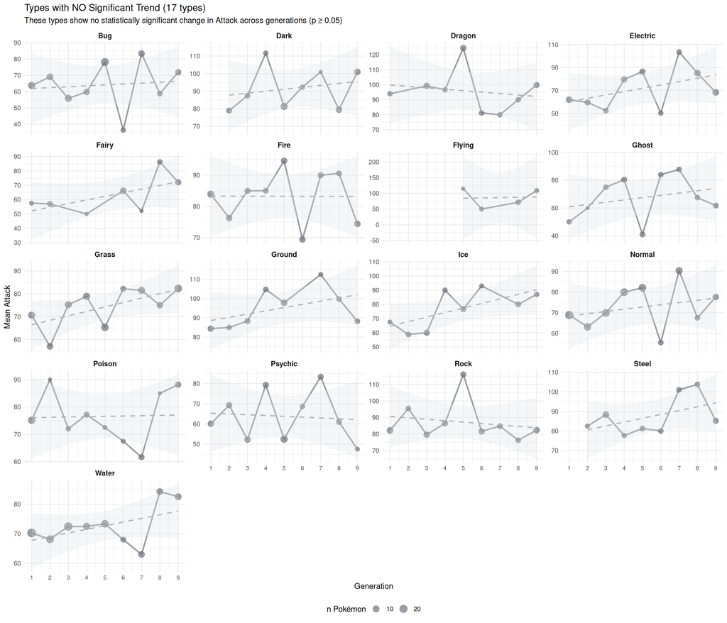

```r
# Plot trends for NON-SIGNIFICANT types (all the rest)
nonsig_types <- type_trends %>%
  filter(direction == "No trend") %>%
  pull(type_name)

n_nonsig <- length(nonsig_types)

if(n_nonsig > 0) {
  type_plot_nonsig <- pokemon %>%
    filter(type_name %in% nonsig_types) %>%
    group_by(type_name, gen_numeric) %>%
    summarise(mean_attack = mean(attack), n = n(), .groups = "drop") %>%
    left_join(type_trends %>% dplyr::select(type_name, slope, p_value), by = "type_name")

  ggplot(type_plot_nonsig, aes(x = gen_numeric, y = mean_attack)) +
    geom_line(linewidth = 1, alpha = 0.7, color = "#6c757d") +
    geom_point(aes(size = n), alpha = 0.7, color = "#6c757d") +
    geom_smooth(method = "lm", se = TRUE, linetype = "dashed",
                linewidth = 0.8, color = "#adb5bd", fill = "#dee2e6", alpha = 0.3) +
    scale_x_continuous(breaks = 1:9) +
    scale_size_continuous(range = c(2, 5), name = "n Pokémon") +
    facet_wrap(~type_name, ncol = 4, scales = "free_y") +
    labs(title = paste0("Types with NO Significant Trend (", n_nonsig, " types)"),
         subtitle = "These types show no statistically significant change in Attack across generations (p ≥ 0.05)",
         x = "Generation", y = "Mean Attack") +
    theme_minimal() +
    theme(legend.position = "bottom",
          strip.text = element_text(face = "bold", size = 10),
          axis.text.x = element_text(size = 8))
} else {
  cat("All types show statistically significant trends at p < 0.05!\n")
}
```

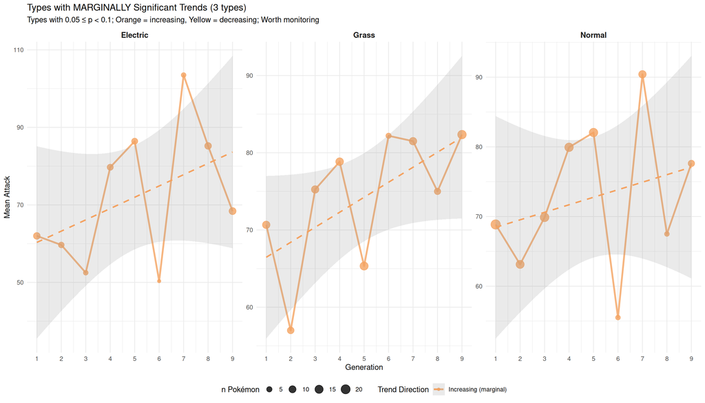

```r
# Plot trends for MARGINALLY SIGNIFICANT types (0.05 ≤ p < 0.1)
marginal_types <- type_trends %>%
  filter(p_value >= 0.05 & p_value < 0.1) %>%
  mutate(
    direction_marginal = case_when(
      slope > 0 ~ "Increasing (marginal)",
      slope < 0 ~ "Decreasing (marginal)",
      TRUE ~ "No trend"
    )
  )

n_marginal <- nrow(marginal_types)

if(n_marginal > 0) {
  type_plot_marginal <- pokemon %>%
    filter(type_name %in% marginal_types$type_name) %>%
    group_by(type_name, gen_numeric) %>%
    summarise(mean_attack = mean(attack), n = n(), .groups = "drop") %>%
    left_join(marginal_types %>% dplyr::select(type_name, direction_marginal, slope, p_value),
              by = "type_name")

  ggplot(type_plot_marginal, aes(x = gen_numeric, y = mean_attack, color = direction_marginal)) +
    geom_line(linewidth = 1.2, alpha = 0.8) +
    geom_point(aes(size = n), alpha = 0.8) +
    geom_smooth(method = "lm", se = TRUE, linetype = "dashed", linewidth = 1, alpha = 0.2) +
    scale_x_continuous(breaks = 1:9) +
    scale_size_continuous(range = c(2, 6), name = "n Pokémon") +
    scale_color_manual(values = c("Increasing (marginal)" = "#F4A261",
                                   "Decreasing (marginal)" = "#E9C46A"),
                       name = "Trend Direction") +
    facet_wrap(~type_name, ncol = 3, scales = "free_y") +
    labs(title = paste0("Types with MARGINALLY Significant Trends (", n_marginal, " types)"),
         subtitle = "Types with 0.05 ≤ p < 0.1; Orange = increasing, Yellow = decreasing; Worth monitoring",
         x = "Generation", y = "Mean Attack") +
    theme_minimal() +
    theme(legend.position = "bottom",
          strip.text = element_text(face = "bold", size = 11),
          axis.text.x = element_text(size = 9))
} else {
  cat("No types show marginally significant trends (0.05 ≤ p < 0.1)\n")
}
```

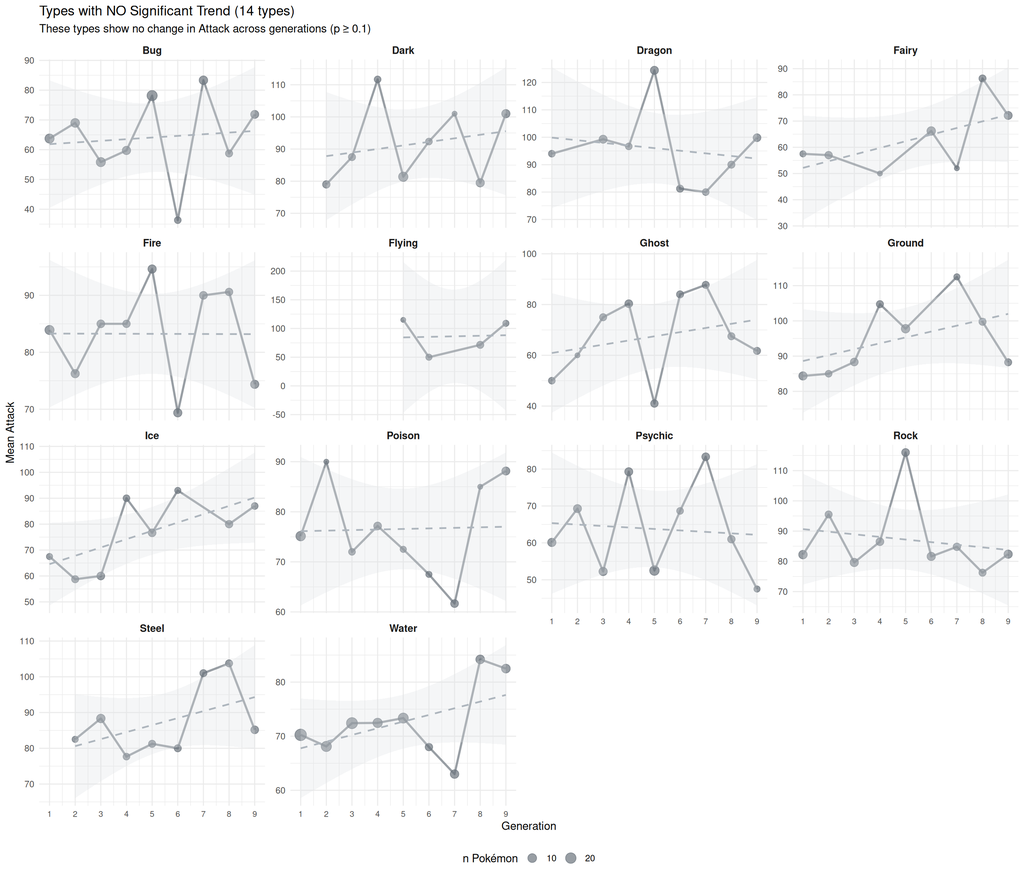

```r
# Plot trends for NON-SIGNIFICANT types (p >= 0.1)
nonsig_strict_types <- type_trends %>%
  filter(p_value >= 0.1) %>%
  pull(type_name)

n_nonsig_strict <- length(nonsig_strict_types)

if(n_nonsig_strict > 0) {
  type_plot_nonsig_strict <- pokemon %>%
    filter(type_name %in% nonsig_strict_types) %>%
    group_by(type_name, gen_numeric) %>%
    summarise(mean_attack = mean(attack), n = n(), .groups = "drop") %>%
    left_join(type_trends %>% dplyr::select(type_name, slope, p_value), by = "type_name")

  ggplot(type_plot_nonsig_strict, aes(x = gen_numeric, y = mean_attack)) +
    geom_line(linewidth = 1, alpha = 0.7, color = "#6c757d") +
    geom_point(aes(size = n), alpha = 0.7, color = "#6c757d") +
    geom_smooth(method = "lm", se = TRUE, linetype = "dashed",
                linewidth = 0.8, color = "#adb5bd", fill = "#dee2e6", alpha = 0.3) +
    scale_x_continuous(breaks = 1:9) +
    scale_size_continuous(range = c(2, 5), name = "n Pokémon") +
    facet_wrap(~type_name, ncol = 4, scales = "free_y") +
    labs(title = paste0("Types with NO Significant Trend (", n_nonsig_strict, " types)"),
         subtitle = "These types show no change in Attack across generations (p ≥ 0.1)",
         x = "Generation", y = "Mean Attack") +
    theme_minimal() +
    theme(legend.position = "bottom",
          strip.text = element_text(face = "bold", size = 10),
          axis.text.x = element_text(size = 8))
} else {
  cat("All types show at least marginally significant trends!\n")
}
```